# Project: Houses Prices data

- Introduction
- Baseline Model
- Data Wrangling
- Exploratory Data Analysis
- 1- Understand The Data
- 2- Clean The Data
- 3- Analysis of Relationship Between Variables
- Modeling
- Conclusion

```python
import numpy as np
import pandas as pd
import matplotlib.pyplot as plt
import seaborn as sns
%matplotlib inline
#plt.style.use('seaborn') #ggplot

from sklearn.linear_model import LinearRegression
from sklearn.model_selection import train_test_split
from sklearn.metrics import mean_squared_error, mean_absolute_error
from sklearn.preprocessing import MinMaxScaler
```

## Introduction

#### About the data:

The real estate markets, like those in Sydney and Melbourne, present an interesting opportunity for data analysts to analyze and predict where property prices are moving towards. Prediction of property prices is becoming increasingly important and beneficial. Property prices are a good indicator of both the overall market condition and the economic health of a country.

#### Columns:

- Date: Date when the house is ready for sale.
- Price: Price of the house to be sold.
- Bedrooms: No. of bedrooms in the house.
- Bathrooms: No. of bathrooms in the house.
- Sqft_living: Squarefoot of Living in the house.
- Sqft_lot: Squarefoot of Floor in the house.
- Floors: Floors on which living area located.
- Waterfront: If waterfront available in front of house.
- View: Vie from the house.
- Condition: Condition of the house.
- Sqft_above: Squarefoot above is the space available at roof.
- Sqft_basement: Squarefoot basement is the space available at the basement.
- Yr_built: In which year the house is built.
- Yr_renovated: Year of renovation.
- Street: On which street house is located.
- City: City in which the country is located.
- Statezip: Zip code of the area in which house is located.
- Country: Country is US.

```python
data = pd.read_csv("data.csv")
```

```python
data.head()
```

|  | date | price | bedrooms | bathrooms | sqft_living | sqft_lot | floors | waterfront | view | condition | sqft_above | sqft_basement | yr_built | yr_renovated | street | city | statezip | country |
| --- | --- | --- | --- | --- | --- | --- | --- | --- | --- | --- | --- | --- | --- | --- | --- | --- | --- | --- |
| 0 | 2014-05-02 00:00:00 | 313000.0 | 3.0 | 1.50 | 1340 | 7912 | 1.5 | 0 | 0 | 3 | 1340 | 0 | 1955 | 2005 | 18810 Densmore Ave N | Shoreline | WA 98133 | USA |
| 1 | 2014-05-02 00:00:00 | 2384000.0 | 5.0 | 2.50 | 3650 | 9050 | 2.0 | 0 | 4 | 5 | 3370 | 280 | 1921 | 0 | 709 W Blaine St | Seattle | WA 98119 | USA |
| 2 | 2014-05-02 00:00:00 | 342000.0 | 3.0 | 2.00 | 1930 | 11947 | 1.0 | 0 | 0 | 4 | 1930 | 0 | 1966 | 0 | 26206-26214 143rd Ave SE | Kent | WA 98042 | USA |
| 3 | 2014-05-02 00:00:00 | 420000.0 | 3.0 | 2.25 | 2000 | 8030 | 1.0 | 0 | 0 | 4 | 1000 | 1000 | 1963 | 0 | 857 170th Pl NE | Bellevue | WA 98008 | USA |
| 4 | 2014-05-02 00:00:00 | 550000.0 | 4.0 | 2.50 | 1940 | 10500 | 1.0 | 0 | 0 | 4 | 1140 | 800 | 1976 | 1992 | 9105 170th Ave NE | Redmond | WA 98052 | USA |

## Baseline Model

A baseline model is essentially a simple model that acts as a reference in a machine learning project. Its main function is to contextualize the results of trained models.

Baseline models usually lack complexity and may have little predictive power. Regardless, their inclusion is a necessity for many reasons.

#### Benefits

There is a very strong case for building baseline models prior to any other model.

Baseline models are not only very easy to build, but they also provide a lot of information that can dictate the future steps in a machine learning project.

```python
bModel = data.copy()
```

#### Checking our model accuracy in the starting

```python
X = bModel.drop(["date",'street', 'city','statezip', 'country','price'], axis=1)
y = bModel[['price']]

train_X, test_X, train_y, test_y= train_test_split(X,y, test_size=0.3, random_state=0)

mlrm = LinearRegression()

mlrm.fit(train_X,train_y)
```

```
LinearRegression()
```

```python
mlrm.score(train_X, train_y)*100   # Predict 'price' from train data
```

```
39.11839148648858
```

```python
from sklearn.metrics import r2_score
ypred = mlrm.predict(train_X)     # another way to Predict 'price' from train data
r2_score(train_y,ypred)*100
```

```
39.11839148648858
```

```python
mlrm.score(test_X, test_y)*100  # Predict 'price' from test data
```

```
9.612104439332692
```

### Conclusion ------> Poor score, but that's what do we expect from raw data

## Data Wrangling

### General Properties

```python
df = data.copy()
```

```python
df.head()
# df.shape
```

|  | date | price | bedrooms | bathrooms | sqft_living | sqft_lot | floors | waterfront | view | condition | sqft_above | sqft_basement | yr_built | yr_renovated | street | city | statezip | country |
| --- | --- | --- | --- | --- | --- | --- | --- | --- | --- | --- | --- | --- | --- | --- | --- | --- | --- | --- |
| 0 | 2014-05-02 00:00:00 | 313000.0 | 3.0 | 1.50 | 1340 | 7912 | 1.5 | 0 | 0 | 3 | 1340 | 0 | 1955 | 2005 | 18810 Densmore Ave N | Shoreline | WA 98133 | USA |
| 1 | 2014-05-02 00:00:00 | 2384000.0 | 5.0 | 2.50 | 3650 | 9050 | 2.0 | 0 | 4 | 5 | 3370 | 280 | 1921 | 0 | 709 W Blaine St | Seattle | WA 98119 | USA |
| 2 | 2014-05-02 00:00:00 | 342000.0 | 3.0 | 2.00 | 1930 | 11947 | 1.0 | 0 | 0 | 4 | 1930 | 0 | 1966 | 0 | 26206-26214 143rd Ave SE | Kent | WA 98042 | USA |
| 3 | 2014-05-02 00:00:00 | 420000.0 | 3.0 | 2.25 | 2000 | 8030 | 1.0 | 0 | 0 | 4 | 1000 | 1000 | 1963 | 0 | 857 170th Pl NE | Bellevue | WA 98008 | USA |
| 4 | 2014-05-02 00:00:00 | 550000.0 | 4.0 | 2.50 | 1940 | 10500 | 1.0 | 0 | 0 | 4 | 1140 | 800 | 1976 | 1992 | 9105 170th Ave NE | Redmond | WA 98052 | USA |

### Chcking if there is null values or not

```python
df.info()
# df.isnull().sum()
```

```
<class 'pandas.core.frame.DataFrame'>
RangeIndex: 4600 entries, 0 to 4599
Data columns (total 18 columns):
 #   Column         Non-Null Count  Dtype
---  ------         --------------  -----
 0   date           4600 non-null   object
 1   price          4600 non-null   float64
 2   bedrooms       4600 non-null   float64
 3   bathrooms      4600 non-null   float64
 4   sqft_living    4600 non-null   int64
 5   sqft_lot       4600 non-null   int64
 6   floors         4600 non-null   float64
 7   waterfront     4600 non-null   int64
 8   view           4600 non-null   int64
 9   condition      4600 non-null   int64
 10  sqft_above     4600 non-null   int64
 11  sqft_basement  4600 non-null   int64
 12  yr_built       4600 non-null   int64
 13  yr_renovated   4600 non-null   int64
 14  street         4600 non-null   object
 15  city           4600 non-null   object
 16  statezip       4600 non-null   object
 17  country        4600 non-null   object
dtypes: float64(4), int64(9), object(5)
memory usage: 647.0+ KB
```

```python
df.describe()
```

|  | price | bedrooms | bathrooms | sqft_living | sqft_lot | floors | waterfront | view | condition | sqft_above | sqft_basement | yr_built | yr_renovated |
| --- | --- | --- | --- | --- | --- | --- | --- | --- | --- | --- | --- | --- | --- |
| count | 4.600000e+03 | 4600.000000 | 4600.000000 | 4600.000000 | 4.600000e+03 | 4600.000000 | 4600.000000 | 4600.000000 | 4600.000000 | 4600.000000 | 4600.000000 | 4600.000000 | 4600.000000 |
| mean | 5.519630e+05 | 3.400870 | 2.160815 | 2139.346957 | 1.485252e+04 | 1.512065 | 0.007174 | 0.240652 | 3.451739 | 1827.265435 | 312.081522 | 1970.786304 | 808.608261 |
| std | 5.638347e+05 | 0.908848 | 0.783781 | 963.206916 | 3.588444e+04 | 0.538288 | 0.084404 | 0.778405 | 0.677230 | 862.168977 | 464.137228 | 29.731848 | 979.414536 |
| min | 0.000000e+00 | 0.000000 | 0.000000 | 370.000000 | 6.380000e+02 | 1.000000 | 0.000000 | 0.000000 | 1.000000 | 370.000000 | 0.000000 | 1900.000000 | 0.000000 |
| 25% | 3.228750e+05 | 3.000000 | 1.750000 | 1460.000000 | 5.000750e+03 | 1.000000 | 0.000000 | 0.000000 | 3.000000 | 1190.000000 | 0.000000 | 1951.000000 | 0.000000 |
| 50% | 4.609435e+05 | 3.000000 | 2.250000 | 1980.000000 | 7.683000e+03 | 1.500000 | 0.000000 | 0.000000 | 3.000000 | 1590.000000 | 0.000000 | 1976.000000 | 0.000000 |
| 75% | 6.549625e+05 | 4.000000 | 2.500000 | 2620.000000 | 1.100125e+04 | 2.000000 | 0.000000 | 0.000000 | 4.000000 | 2300.000000 | 610.000000 | 1997.000000 | 1999.000000 |
| max | 2.659000e+07 | 9.000000 | 8.000000 | 13540.000000 | 1.074218e+06 | 3.500000 | 1.000000 | 4.000000 | 5.000000 | 9410.000000 | 4820.000000 | 2014.000000 | 2014.000000 |

### Chcking if there are 0s values or not

```python
df[df==0].count()
```

```
date                0
price              49
bedrooms            2
bathrooms           2
sqft_living         0
sqft_lot            0
floors              0
waterfront       4567
view             4140
condition           0
sqft_above          0
sqft_basement    2745
yr_built            0
yr_renovated     2735
street              0
city                0
statezip            0
country             0
dtype: int64
```

The data have got larg of 0s in their values

- So let's Understand The Data Firstly

## Exploratory Data Analysis

### Understand The Data

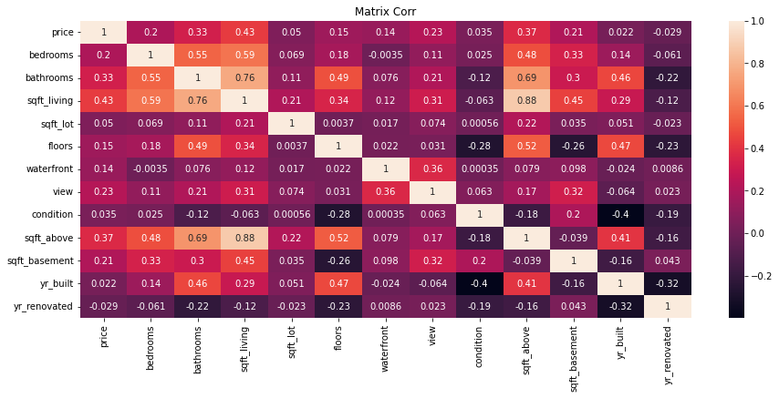

```python
fig = plt.figure(figsize=(15,6))
sns.heatmap(df.corr(), annot=True)
plt.title("Matrix Corr")
```

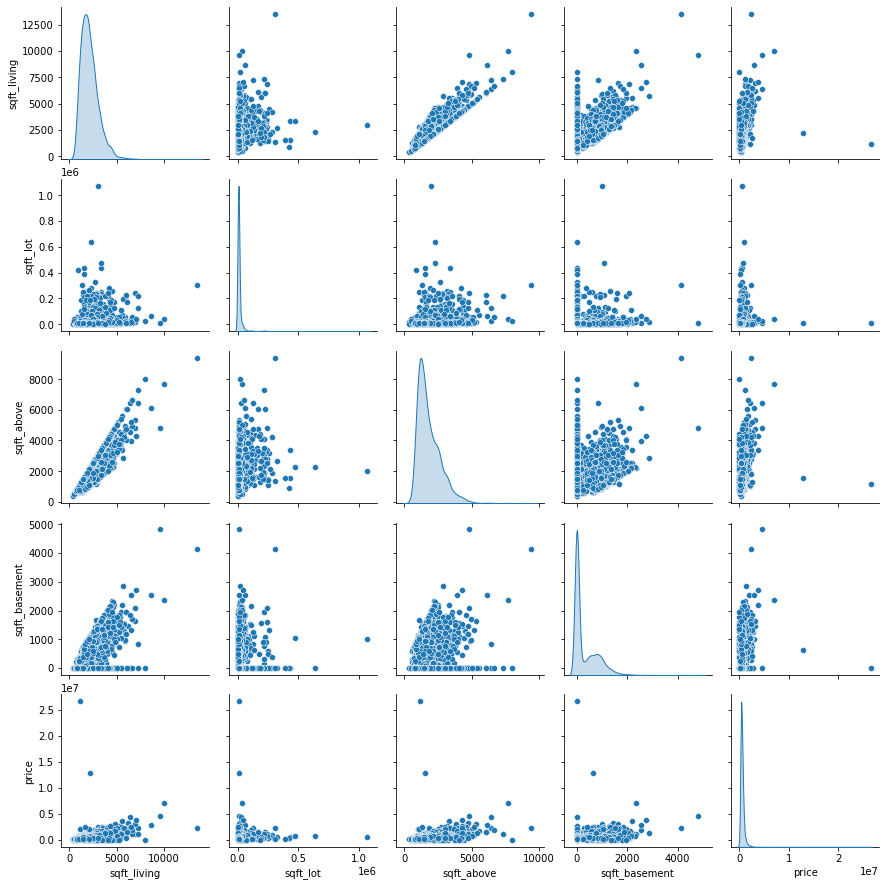

```python
pair_cols = ["sqft_living", "sqft_lot", "sqft_above", "sqft_basement", "price"]

plt.figure()
sns.pairplot(df[(pair_cols)], palette='tab10', diag_kind='kde')
plt.show()
```

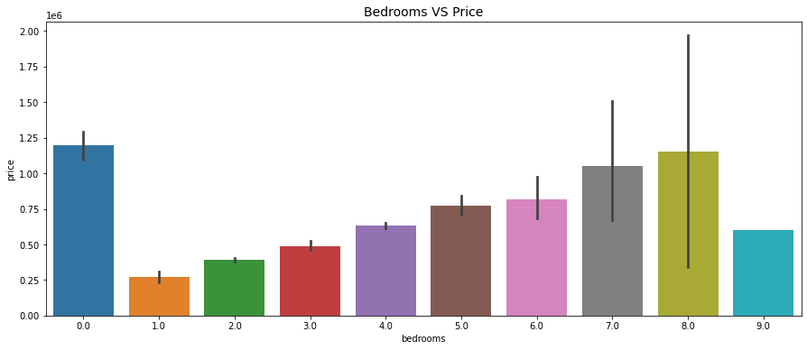

```python
plt.figure(figsize=(15,6))
ax = sns.barplot(x=df['bedrooms'], y=df['price'])
ax.set_xticklabels(ax.get_xticklabels(), rotation=0)
ax.set_title('Bedrooms VS Price', fontsize=14)
```

```python
bedroom = df.groupby(['bedrooms']).price.agg([len, min, max])
bedroom
```

| bedrooms | len | min | max |
| --- | --- | --- | --- |
| 0.0 | 2 | 1095000.0 | 1295648.0 |
| 1.0 | 38 | 0.0 | 540000.0 |
| 2.0 | 566 | 0.0 | 1695000.0 |
| 3.0 | 2032 | 0.0 | 26590000.0 |
| 4.0 | 1531 | 0.0 | 4489000.0 |
| 5.0 | 353 | 0.0 | 7062500.0 |
| 6.0 | 61 | 0.0 | 3100000.0 |
| 7.0 | 14 | 280000.0 | 3200000.0 |
| 8.0 | 2 | 340000.0 | 1970000.0 |
| 9.0 | 1 | 599999.0 | 599999.0 |

We can leave it as it ease or we can change it also!! I personally think let's deal with it because less than 20 rows have more than 6 bedrooms and it will might lead to disturbance in our distribution.

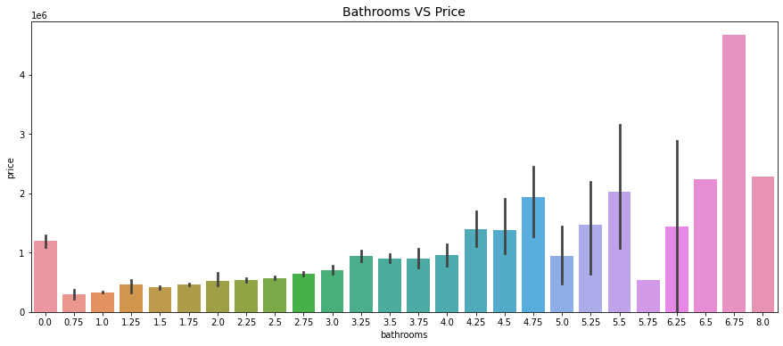

```python
plt.figure(figsize=(15,6))
ax = sns.barplot(x=df['bathrooms'], y=df['price'])
ax.set_xticklabels(ax.get_xticklabels(), rotation=0)
ax.set_title('Bathrooms VS Price', fontsize=14)
```

```python
df.groupby(['bathrooms']).price.agg([len, min, max])
```

| bathrooms | len | min | max |
| --- | --- | --- | --- |
| 0.00 | 2 | 1095000.0 | 1295648.0 |
| 0.75 | 17 | 80000.0 | 562100.0 |
| 1.00 | 743 | 0.0 | 2110000.0 |
| 1.25 | 3 | 321950.0 | 545000.0 |
| 1.50 | 291 | 0.0 | 2199900.0 |
| 1.75 | 629 | 0.0 | 2100000.0 |
| 2.00 | 427 | 0.0 | 26590000.0 |
| 2.25 | 419 | 0.0 | 2400000.0 |
| 2.50 | 1189 | 0.0 | 12899000.0 |
| 2.75 | 276 | 0.0 | 2180000.0 |
| 3.00 | 167 | 0.0 | 4489000.0 |
| 3.25 | 136 | 0.0 | 2750000.0 |
| 3.50 | 162 | 0.0 | 3710000.0 |
| 3.75 | 37 | 0.0 | 2065000.0 |
| 4.00 | 23 | 0.0 | 2000000.0 |
| 4.25 | 23 | 0.0 | 3100000.0 |
| 4.50 | 29 | 0.0 | 7062500.0 |
| 4.75 | 7 | 480000.0 | 2700000.0 |
| 5.00 | 6 | 0.0 | 1800000.0 |
| 5.25 | 4 | 300000.0 | 2458000.0 |
| 5.50 | 4 | 925000.0 | 3800000.0 |
| 5.75 | 1 | 540000.0 | 540000.0 |
| 6.25 | 2 | 0.0 | 2888000.0 |
| 6.50 | 1 | 2238888.0 | 2238888.0 |
| 6.75 | 1 | 4668000.0 | 4668000.0 |
| 8.00 | 1 | 2280000.0 | 2280000.0 |

See, personally I don't have idea about 1.25, 1.75 kind of bethrooms but it doesn't seems an error because we have alot more entries like that.

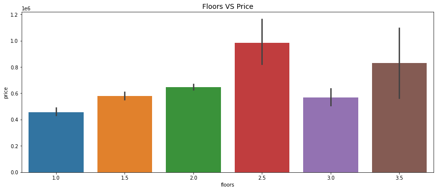

```python
plt.figure(figsize=(15,6))
ax = sns.barplot(x=df['floors'], y=df['price'])
ax.set_xticklabels(ax.get_xticklabels(), rotation=0)
ax.set_title('Floors VS Price', fontsize=14)
```

```python
floor = df.groupby(['floors']).price.agg([len , min, max])
floor
```

| floors | len | min | max |
| --- | --- | --- | --- |
| 1.0 | 2174 | 0.0 | 26590000.0 |
| 1.5 | 444 | 0.0 | 2453500.0 |
| 2.0 | 1811 | 0.0 | 7062500.0 |
| 2.5 | 41 | 195000.0 | 3200000.0 |
| 3.0 | 128 | 0.0 | 3100000.0 |
| 3.5 | 2 | 563500.0 | 1095000.0 |

Only two houses have 3.5 floors. Handling this by replacing it with 3.0 floors.

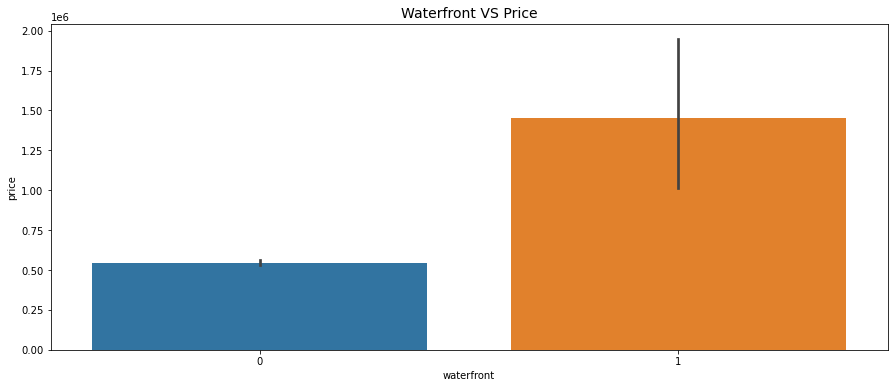

```python
plt.figure(figsize=(15,6))
ax = sns.barplot(x=df['waterfront'], y=df['price'])
ax.set_xticklabels(ax.get_xticklabels(), rotation=0)
ax.set_title('Waterfront VS Price', fontsize=14)
```

```python
waterfront = df.groupby(['waterfront']).price.agg([len , min, max])
waterfront
```

| waterfront | len | min | max |
| --- | --- | --- | --- |
| 0 | 4567 | 0.0 | 26590000.0 |
| 1 | 33 | 0.0 | 7062500.0 |

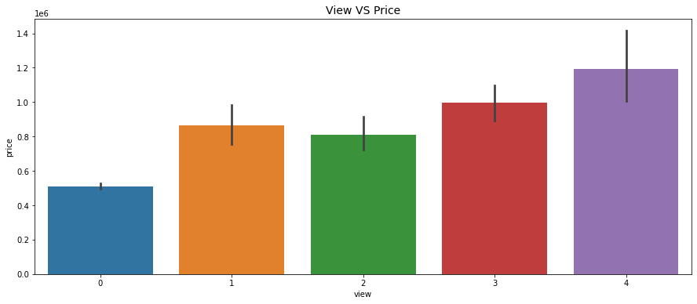

```python
plt.figure(figsize=(15,6))
ax = sns.barplot(x=df['view'], y=df['price'])
ax.set_xticklabels(ax.get_xticklabels(), rotation=0)
ax.set_title('View VS Price', fontsize=14)
```

```python
view = df.groupby(['view']).price.agg([len , min, max])
view
```

| view | len | min | max |
| --- | --- | --- | --- |
| 0 | 4140 | 0.000000 | 26590000.0 |
| 1 | 69 | 180785.714286 | 2400000.0 |
| 2 | 205 | 0.000000 | 7062500.0 |
| 3 | 116 | 0.000000 | 2475000.0 |
| 4 | 70 | 0.000000 | 4668000.0 |

Well no need for any changes. 0 view is for houses having no sea facing view or anything like that. So it seems pretty authentic to me.

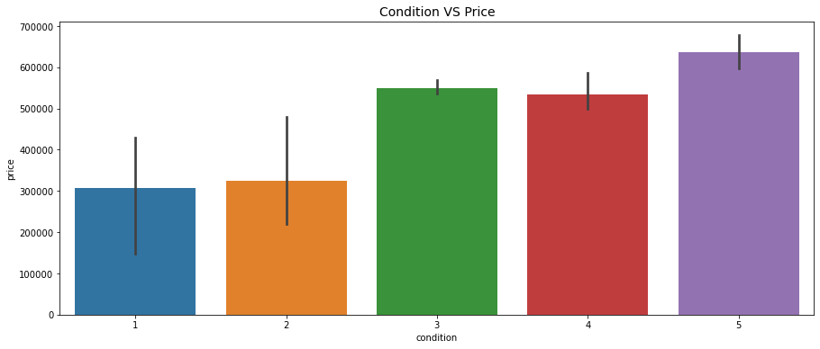

```python
plt.figure(figsize=(15,6))
ax = sns.barplot(x=df['condition'], y=df['price'])
ax.set_xticklabels(ax.get_xticklabels(), rotation=0)
ax.set_title('Condition VS Price', fontsize=14)
```

```python
condition = df.groupby(['condition']).price.agg([len , min, max])
condition
```

| condition | len | min | max |
| --- | --- | --- | --- |
| 1 | 6 | 7800.0 | 550000.0 |
| 2 | 32 | 0.0 | 2555000.0 |
| 3 | 2875 | 0.0 | 12899000.0 |
| 4 | 1252 | 0.0 | 26590000.0 |
| 5 | 435 | 0.0 | 3200000.0 |

Possibly the condition here is for the condition of house and I assuming 5 as best condition and 1 as the worst.

But 1 has just 6 houses that means USA is a country of good conditioned houses.

Well just one change for me to replace 1 with 2. That's all.

Done with the Discrete columns here. Yr_built & yr_renovated are out of two least correlated columns with price. Thus, decided to leave them as it is.

```python
df['country'].nunique()
```

```
1
```

All the entries have common country, will never affect our dependent variable. Will drop it later.

```python
df['street'].nunique()
```

```
4525
```

Too many unique values for 4600 entries, again will never affect our dependent variable. Will drop it later.

ust left with city and statezip. Here we all know satezip and city are quite relateable things. Like every city has a unique zip code. So, we have to choose wisely one out of these two columns.

```python
df['city'].nunique()
```

```
44
```

```python
df['statezip'].nunique()
```

```
77
```

As we can observe, city has 44 unique values and statezip has 77. Let's see which variable has more impact to price

```python
city = df.groupby(['city']).price.agg([len, min, max])
pd.set_option('display.max_rows',70)
city
```

| city | len | min | max |
| --- | --- | --- | --- |
| Algona | 5 | 100000.000000 | 262000.0 |
| Auburn | 176 | 0.000000 | 900000.0 |
| Beaux Arts Village | 1 | 745000.000000 | 745000.0 |
| Bellevue | 286 | 0.000000 | 7062500.0 |
| Black Diamond | 9 | 0.000000 | 650000.0 |
| Bothell | 33 | 347000.000000 | 749995.0 |
| Burien | 74 | 0.000000 | 1035000.0 |
| Carnation | 22 | 80000.000000 | 1680000.0 |
| Clyde Hill | 11 | 0.000000 | 3800000.0 |
| Covington | 43 | 0.000000 | 2199900.0 |
| Des Moines | 58 | 140000.000000 | 950000.0 |
| Duvall | 42 | 117833.333333 | 955000.0 |
| Enumclaw | 28 | 0.000000 | 687000.0 |
| Fall City | 11 | 275000.000000 | 1600000.0 |
| Federal Way | 148 | 0.000000 | 819000.0 |
| Inglewood-Finn Hill | 1 | 425000.000000 | 425000.0 |
| Issaquah | 187 | 0.000000 | 2238888.0 |
| Kenmore | 66 | 0.000000 | 1120000.0 |
| Kent | 185 | 0.000000 | 26590000.0 |
| Kirkland | 187 | 90000.000000 | 3000000.0 |
| Lake Forest Park | 36 | 0.000000 | 790000.0 |
| Maple Valley | 96 | 0.000000 | 725000.0 |
| Medina | 11 | 188000.000000 | 3710000.0 |
| Mercer Island | 86 | 0.000000 | 4668000.0 |
| Milton | 2 | 250000.000000 | 320000.0 |
| Newcastle | 33 | 339900.000000 | 1200000.0 |
| Normandy Park | 18 | 0.000000 | 1309500.0 |
| North Bend | 50 | 240000.000000 | 845000.0 |
| Pacific | 6 | 174000.000000 | 260000.0 |
| Preston | 2 | 439900.000000 | 685000.0 |
| Ravensdale | 7 | 225000.000000 | 792500.0 |
| Redmond | 235 | 170000.000000 | 2280000.0 |
| Renton | 293 | 0.000000 | 1135250.0 |
| Sammamish | 175 | 0.000000 | 2400000.0 |
| SeaTac | 29 | 0.000000 | 489000.0 |
| Seattle | 1573 | 0.000000 | 12899000.0 |
| Shoreline | 123 | 176225.000000 | 2005000.0 |
| Skykomish | 3 | 134000.000000 | 415000.0 |
| Snoqualmie | 71 | 0.000000 | 1149000.0 |
| Snoqualmie Pass | 1 | 525000.000000 | 525000.0 |
| Tukwila | 29 | 7800.000000 | 2110000.0 |
| Vashon | 29 | 160000.000000 | 849900.0 |
| Woodinville | 115 | 0.000000 | 1820000.0 |
| Yarrow Point | 4 | 84350.000000 | 1901000.0 |

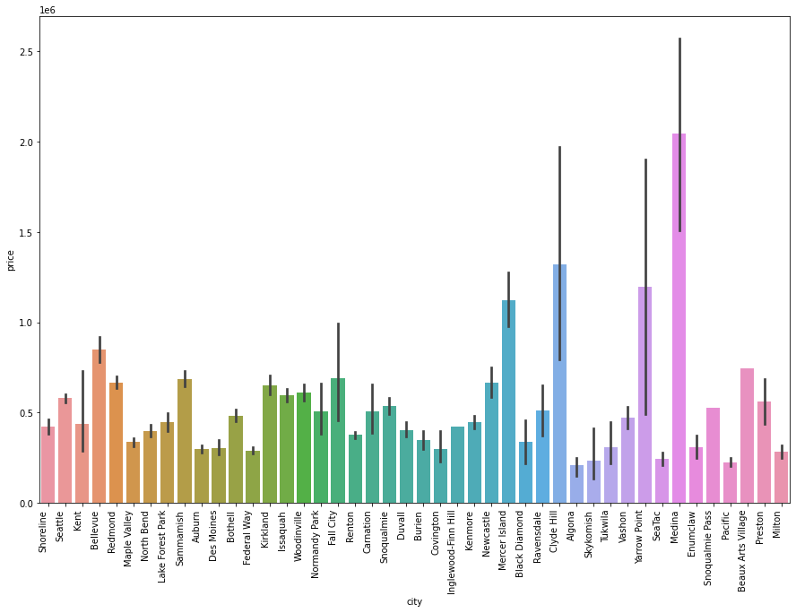

```python
plt.figure(figsize=(15,10))
ax = sns.barplot(x="city", y="price", data=df)
ax.set_xticklabels(ax.get_xticklabels(), rotation=90, ha="right");
```

```python
statezip = df.groupby(['statezip']).price.agg([len, min, max])
pd.set_option('display.max_rows',70)
statezip
```

| statezip | len | min | max |
| --- | --- | --- | --- |
| WA 98001 | 67 | 0.000000 | 625000.0 |
| WA 98002 | 36 | 0.000000 | 340000.0 |
| WA 98003 | 48 | 156000.000000 | 819000.0 |
| WA 98004 | 74 | 0.000000 | 7062500.0 |
| WA 98005 | 29 | 497333.333333 | 1900000.0 |
| ... | ... | ... | ... |
| WA 98188 | 23 | 0.000000 | 489000.0 |
| WA 98198 | 56 | 140000.000000 | 950000.0 |
| WA 98199 | 68 | 0.000000 | 12899000.0 |
| WA 98288 | 3 | 134000.000000 | 415000.0 |
| WA 98354 | 2 | 250000.000000 | 320000.0 |

77 rows × 3 columns

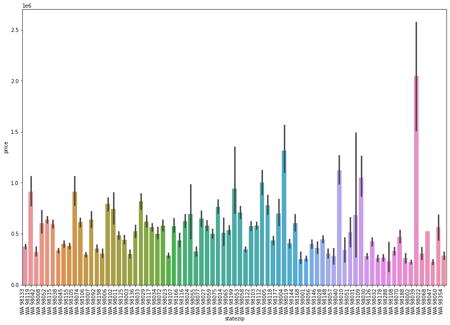

```python
plt.figure(figsize=(15,10))
ax = sns.barplot(x="statezip", y="price", data=df)
ax.set_xticklabels(ax.get_xticklabels(), rotation=90, ha="right");
```

You can observe a litle high variation in statezip in comparison to city. So I'have selected our final column that is statezip.

So I will drop street, city and country before moving forward.

### Clean The Data

```python
df[df==0].count()
```

```
date                0
price              49
bedrooms            2
bathrooms           2
sqft_living         0
sqft_lot            0
floors              0
waterfront       4567
view             4140
condition           0
sqft_above          0
sqft_basement    2745
yr_built            0
yr_renovated     2735
street              0
city                0
statezip            0
country             0
dtype: int64
```

But, it is really hard to digest a house with 0 bedrooms and 0 bathrooms, and impossible to have any house with 0 price, who'll sell a house for free.

Let's look into it with closer insights.

```python
df[df["price"]==0]
```

|  | date | price | bedrooms | bathrooms | sqft_living | sqft_lot | floors | waterfront | view | condition | sqft_above | sqft_basement | yr_built | yr_renovated | street | city | statezip | country |
| --- | --- | --- | --- | --- | --- | --- | --- | --- | --- | --- | --- | --- | --- | --- | --- | --- | --- | --- |
| 4354 | 2014-05-05 00:00:00 | 0.0 | 3.0 | 1.75 | 1490 | 10125 | 1.0 | 0 | 0 | 4 | 1490 | 0 | 1962 | 0 | 3911 S 328th St | Federal Way | WA 98001 | USA |
| 4356 | 2014-05-05 00:00:00 | 0.0 | 4.0 | 2.75 | 2600 | 5390 | 1.0 | 0 | 0 | 4 | 1300 | 1300 | 1960 | 2001 | 2120 31st Ave W | Seattle | WA 98199 | USA |
| 4357 | 2014-05-05 00:00:00 | 0.0 | 6.0 | 2.75 | 3200 | 9200 | 1.0 | 0 | 2 | 4 | 1600 | 1600 | 1953 | 1983 | 12271 Marine View Dr SW | Burien | WA 98146 | USA |
| 4358 | 2014-05-06 00:00:00 | 0.0 | 5.0 | 3.50 | 3480 | 36615 | 2.0 | 0 | 0 | 4 | 2490 | 990 | 1983 | 0 | 21809 SE 38th Pl | Issaquah | WA 98075 | USA |
| 4361 | 2014-05-07 00:00:00 | 0.0 | 5.0 | 1.50 | 1500 | 7112 | 1.0 | 0 | 0 | 5 | 760 | 740 | 1920 | 0 | 14901-14999 12th Ave SW | Burien | WA 98166 | USA |
| 4362 | 2014-05-07 00:00:00 | 0.0 | 4.0 | 4.00 | 3680 | 18804 | 2.0 | 0 | 0 | 3 | 3680 | 0 | 1990 | 2009 | 1223-1237 244th Ave NE | Sammamish | WA 98074 | USA |
| 4374 | 2014-05-09 00:00:00 | 0.0 | 2.0 | 2.50 | 2200 | 188200 | 1.0 | 0 | 3 | 3 | 2200 | 0 | 2007 | 0 | 39612 254th Ave SE | Enumclaw | WA 98022 | USA |
| 4376 | 2014-05-09 00:00:00 | 0.0 | 4.0 | 2.25 | 2170 | 10500 | 1.0 | 0 | 2 | 4 | 1270 | 900 | 1960 | 2001 | 216 SW 183rd St | Normandy Park | WA 98166 | USA |
| 4382 | 2014-05-12 00:00:00 | 0.0 | 5.0 | 4.50 | 4630 | 6324 | 2.0 | 0 | 0 | 3 | 3210 | 1420 | 2006 | 0 | 6925 Oakmont Ave SE | Snoqualmie | WA 98065 | USA |
| 4383 | 2014-05-13 00:00:00 | 0.0 | 5.0 | 4.00 | 4430 | 9000 | 2.0 | 0 | 0 | 3 | 4430 | 0 | 2013 | 1923 | 9235 NE 5th St | Bellevue | WA 98004 | USA |
| 4385 | 2014-05-13 00:00:00 | 0.0 | 4.0 | 4.50 | 5030 | 11023 | 2.0 | 0 | 2 | 3 | 3250 | 1780 | 2008 | 0 | 4140 Boulevard Pl | Mercer Island | WA 98040 | USA |
| 4386 | 2014-05-13 00:00:00 | 0.0 | 4.0 | 1.50 | 2180 | 22870 | 1.0 | 0 | 0 | 4 | 1280 | 900 | 1954 | 1975 | 31603 E Lake Morton Dr SE | Kent | WA 98042 | USA |
| 4389 | 2014-05-15 00:00:00 | 0.0 | 4.0 | 3.50 | 4210 | 10308 | 2.0 | 0 | 0 | 3 | 4210 | 0 | 2006 | 0 | 2234 167th Ave SE | Bellevue | WA 98008 | USA |
| 4394 | 2014-05-16 00:00:00 | 0.0 | 5.0 | 3.25 | 3690 | 12353 | 2.0 | 0 | 0 | 5 | 3690 | 0 | 1977 | 0 | 19055 35th Ave NE | Lake Forest Park | WA 98155 | USA |
| 4405 | 2014-05-20 00:00:00 | 0.0 | 4.0 | 3.75 | 3300 | 4545 | 1.5 | 0 | 4 | 3 | 2600 | 700 | 1926 | 1999 | 3665 50th Ave NE | Seattle | WA 98105 | USA |
| 4408 | 2014-05-21 00:00:00 | 0.0 | 5.0 | 2.25 | 2880 | 11965 | 2.0 | 0 | 0 | 4 | 2880 | 0 | 1990 | 0 | 25437 163rd Pl SE | Covington | WA 98042 | USA |
| 4411 | 2014-05-22 00:00:00 | 0.0 | 5.0 | 2.25 | 2000 | 7900 | 1.0 | 0 | 0 | 4 | 1300 | 700 | 1986 | 0 | 3202 S 194th St | SeaTac | WA 98188 | USA |
| 4412 | 2014-05-22 00:00:00 | 0.0 | 3.0 | 3.00 | 1860 | 7440 | 1.0 | 0 | 0 | 5 | 1040 | 820 | 1954 | 0 | 10744 62nd Ave S | Seattle | WA 98178 | USA |
| 4413 | 2014-05-22 00:00:00 | 0.0 | 4.0 | 3.00 | 1990 | 6180 | 2.0 | 0 | 0 | 3 | 1990 | 0 | 1990 | 2009 | 32706 20th Ave SW | Federal Way | WA 98023 | USA |
| 4420 | 2014-05-27 00:00:00 | 0.0 | 4.0 | 1.00 | 1360 | 13372 | 1.0 | 0 | 0 | 3 | 1360 | 0 | 1955 | 2005 | 18423 61st Pl NE | Kenmore | WA 98028 | USA |
| 4442 | 2014-06-02 00:00:00 | 0.0 | 1.0 | 1.00 | 720 | 6000 | 1.0 | 0 | 0 | 3 | 720 | 0 | 1940 | 1996 | 1236 S Cloverdale St | Seattle | WA 98108 | USA |
| 4448 | 2014-06-03 00:00:00 | 0.0 | 5.0 | 2.75 | 2740 | 5616 | 1.5 | 0 | 0 | 5 | 1670 | 1070 | 1925 | 0 | 1013 NE 80th St | Seattle | WA 98115 | USA |
| 4453 | 2014-06-03 00:00:00 | 0.0 | 3.0 | 1.00 | 1300 | 6710 | 1.0 | 0 | 0 | 4 | 1300 | 0 | 1952 | 0 | 2760 72nd Ave SE | Mercer Island | WA 98040 | USA |
| 4454 | 2014-06-03 00:00:00 | 0.0 | 5.0 | 2.50 | 2090 | 4698 | 2.0 | 0 | 0 | 3 | 2090 | 0 | 1998 | 2006 | 27622 237th Pl SE | Maple Valley | WA 98038 | USA |
| 4472 | 2014-06-09 00:00:00 | 0.0 | 4.0 | 3.75 | 4060 | 19290 | 2.0 | 0 | 0 | 3 | 4060 | 0 | 2002 | 0 | 21418 SE 5th Pl | Sammamish | WA 98074 | USA |
| 4478 | 2014-06-11 00:00:00 | 0.0 | 5.0 | 2.75 | 2910 | 53898 | 1.0 | 0 | 0 | 5 | 1510 | 1400 | 1979 | 0 | 13505 208th Ave NE | Woodinville | WA 98077 | USA |
| 4479 | 2014-06-11 00:00:00 | 0.0 | 5.0 | 2.00 | 1910 | 7200 | 1.0 | 0 | 0 | 4 | 1110 | 800 | 1951 | 1999 | 11620-11698 57th Ave S | Seattle | WA 98178 | USA |
| 4480 | 2014-06-11 00:00:00 | 0.0 | 3.0 | 2.50 | 2880 | 13500 | 1.0 | 0 | 4 | 5 | 1520 | 1360 | 1950 | 0 | 9243 NE 20th St | Clyde Hill | WA 98004 | USA |
| 4481 | 2014-06-11 00:00:00 | 0.0 | 5.0 | 2.75 | 3240 | 6863 | 2.0 | 0 | 0 | 3 | 3240 | 0 | 2013 | 1923 | 1301-1303 Monterey Ave NE | Renton | WA 98056 | USA |
| 4487 | 2014-06-12 00:00:00 | 0.0 | 4.0 | 1.00 | 2080 | 3500 | 1.5 | 0 | 0 | 5 | 1260 | 820 | 1926 | 0 | 6506 40th Ave SW | Seattle | WA 98136 | USA |
| 4499 | 2014-06-17 00:00:00 | 0.0 | 5.0 | 3.75 | 3870 | 8225 | 2.0 | 0 | 0 | 3 | 3870 | 0 | 1998 | 2006 | 101-127 247th Ave SE | Sammamish | WA 98074 | USA |
| 4507 | 2014-06-18 00:00:00 | 0.0 | 4.0 | 1.50 | 2310 | 68824 | 2.0 | 0 | 0 | 4 | 2310 | 0 | 1968 | 0 | 29656 232nd Ave SE | Black Diamond | WA 98010 | USA |
| 4509 | 2014-06-18 00:00:00 | 0.0 | 6.0 | 3.00 | 3020 | 13783 | 2.0 | 0 | 0 | 3 | 3020 | 0 | 1952 | 2002 | 4115 85th Ave SE | Mercer Island | WA 98040 | USA |
| 4520 | 2014-06-20 00:00:00 | 0.0 | 4.0 | 2.50 | 1960 | 11600 | 1.0 | 0 | 0 | 5 | 980 | 980 | 1931 | 0 | 506 21st St SE | Auburn | WA 98002 | USA |
| 4521 | 2014-06-20 00:00:00 | 0.0 | 4.0 | 1.00 | 1810 | 7500 | 1.0 | 0 | 0 | 2 | 1410 | 400 | 1959 | 0 | 12231 Occidental Ave S | Seattle | WA 98168 | USA |
| 4522 | 2014-06-22 00:00:00 | 0.0 | 2.0 | 2.25 | 1490 | 6770 | 1.5 | 0 | 0 | 3 | 1490 | 0 | 1926 | 2003 | 4921 28th Ave S | Seattle | WA 98108 | USA |
| 4523 | 2014-06-23 00:00:00 | 0.0 | 3.0 | 4.50 | 5230 | 17826 | 2.0 | 1 | 4 | 3 | 3740 | 1490 | 2005 | 0 | 7455 W Mercer Way | Mercer Island | WA 98040 | USA |
| 4528 | 2014-06-24 00:00:00 | 0.0 | 4.0 | 5.00 | 4550 | 18641 | 1.0 | 1 | 4 | 3 | 2600 | 1950 | 2002 | 0 | 425 E Lake Sammamish Pkwy SE | Sammamish | WA 98074 | USA |
| 4534 | 2014-06-24 00:00:00 | 0.0 | 3.0 | 2.75 | 1310 | 7300 | 1.0 | 0 | 0 | 3 | 1310 | 0 | 1957 | 2000 | 16232 SE 10th St | Bellevue | WA 98008 | USA |
| 4542 | 2014-06-25 00:00:00 | 0.0 | 5.0 | 3.50 | 2640 | 6895 | 2.0 | 0 | 0 | 3 | 2640 | 0 | 2001 | 0 | 34529 SE Jay Ct | Snoqualmie | WA 98065 | USA |
| 4552 | 2014-06-26 00:00:00 | 0.0 | 4.0 | 2.00 | 2100 | 4857 | 2.0 | 0 | 0 | 3 | 2100 | 0 | 1965 | 1984 | 4500 NE 171st St | Lake Forest Park | WA 98155 | USA |
| 4554 | 2014-06-27 00:00:00 | 0.0 | 2.0 | 1.00 | 810 | 8424 | 1.0 | 0 | 0 | 4 | 810 | 0 | 1959 | 0 | 30401-30499 8th Ave SW | Federal Way | WA 98023 | USA |
| 4555 | 2014-06-27 00:00:00 | 0.0 | 2.0 | 1.50 | 1520 | 8040 | 1.0 | 0 | 0 | 5 | 1520 | 0 | 1951 | 0 | 11533 22nd Ave NE | Seattle | WA 98125 | USA |
| 4558 | 2014-06-28 00:00:00 | 0.0 | 4.0 | 4.25 | 3500 | 8750 | 1.0 | 0 | 4 | 5 | 2140 | 1360 | 1951 | 0 | 12725 8th Ave NW | Seattle | WA 98177 | USA |
| 4563 | 2014-07-01 00:00:00 | 0.0 | 2.0 | 2.25 | 2130 | 4920 | 1.5 | 0 | 4 | 4 | 1530 | 600 | 1941 | 1998 | 3428 60th Ave SW | Seattle | WA 98116 | USA |
| 4567 | 2014-07-02 00:00:00 | 0.0 | 4.0 | 2.50 | 4080 | 18362 | 2.0 | 0 | 2 | 4 | 4080 | 0 | 1983 | 0 | 2710 95th Ave NE | Clyde Hill | WA 98004 | USA |
| 4574 | 2014-07-02 00:00:00 | 0.0 | 3.0 | 1.00 | 1520 | 9030 | 1.0 | 0 | 0 | 3 | 1520 | 0 | 1956 | 2001 | 2533 155th Pl SE | Bellevue | WA 98007 | USA |
| 4575 | 2014-07-02 00:00:00 | 0.0 | 5.0 | 6.25 | 8020 | 21738 | 2.0 | 0 | 0 | 3 | 8020 | 0 | 2001 | 0 | 2 Crescent Key | Bellevue | WA 98006 | USA |
| 4588 | 2014-07-08 00:00:00 | 0.0 | 4.0 | 2.25 | 2890 | 18226 | 3.0 | 1 | 4 | 3 | 2890 | 0 | 1984 | 0 | 3227-3399 Mountain View Ave N | Renton | WA 98056 | USA |

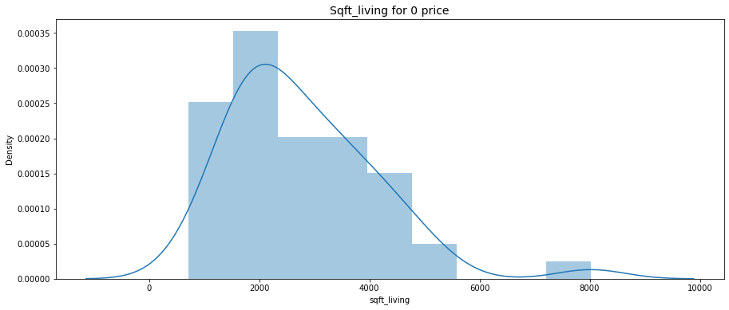

```python
plt.figure(figsize=(15,6))
ax = sns.distplot(df[df["price"]==0].sqft_living)
ax.set_title('Sqft_living for 0 price', fontsize=14)
```

Majority of the 0 price house's sqft_living ranges between 1000-5000.

We have to check its correlation with other columns also.

```python
# df[df["price"]==0].agg([min, max, 'mean', 'median'])
```

As we discussed above these are some major columns on which price depends. So we'll use these to replace 0 prices of houses

```python
# df1 = df[(df.bedrooms == 4) & (df.bathrooms > 1) & (df.bathrooms < 4) & (df.sqft_living > 2500) &
#         (df.sqft_living < 3000) & (df.floors < 3) & (df.yr_built < 1970)]
```

```python
# df1.shape
```

```python
# df1.price.mean()
```

```python
df['price'].replace(to_replace = 0, value = 735000, inplace = True)
# df = df[df['price'] != 0]
```

```python
len(df[(df['price'] == 0)])
```

```
0
```

```python
df[df==0].count()
```

```
date                0
price               0
bedrooms            2
bathrooms           2
sqft_living         0
sqft_lot            0
floors              0
waterfront       4567
view             4140
condition           0
sqft_above          0
sqft_basement    2745
yr_built            0
yr_renovated     2735
street              0
city                0
statezip            0
country             0
dtype: int64
```

### And, it's done!!

Before moving forward let's quickly deal with 0 bedrooms and bathrooms

```python
df =df[(df['bedrooms']!=0) & (df['bathrooms']!=0)]
```

```python
# df[df==0].count()
```

### And, it's done!!

#### Alright then, we've dealt with 0s let's move forward

There are alot of outliers can clearly observed!!

Let's visualize it more clearly!

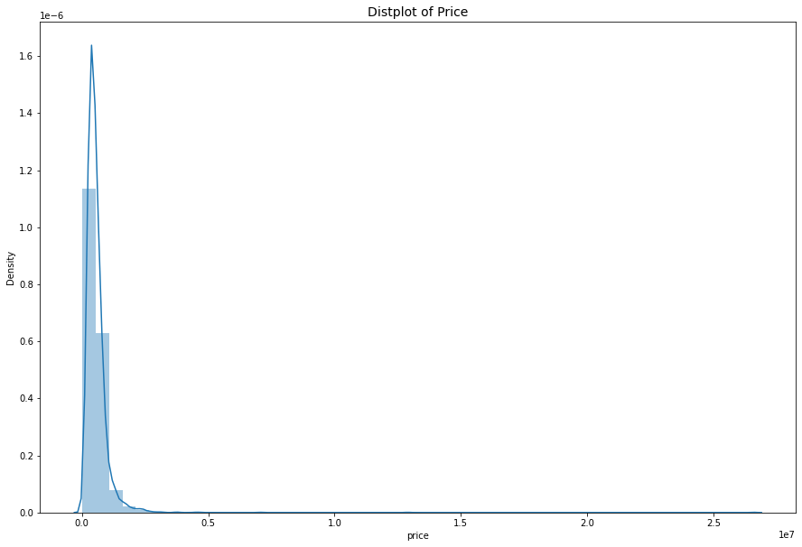

```python
plt.figure(figsize=(15,10))
ax = sns.distplot(df['price'], kde=True)
ax.set_title('Distplot of Price', fontsize=14)
```

```python
from scipy import stats
df['price'] = df['price'].replace([data['price'][np.abs(stats.zscore(data['price'])) > 3]],np.median(df['price']))
```

Handling outliers of price columns. As, it is very important because at last we're predicting price and disturbance in its distribution might hit hard to our predictions.

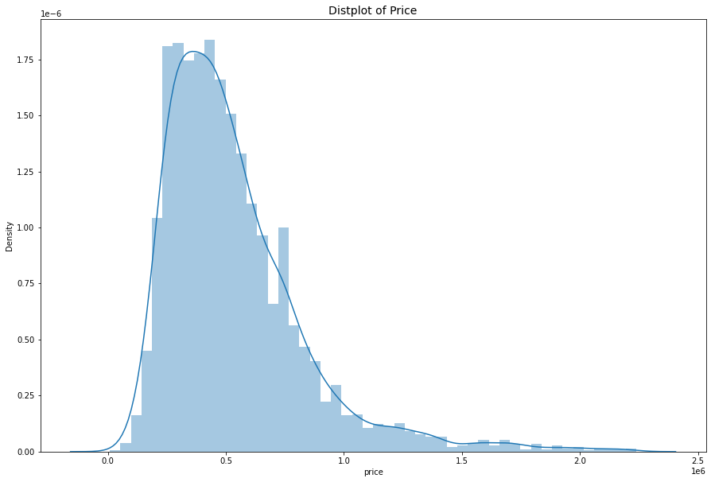

```python
plt.figure(figsize=(15,10))
ax = sns.distplot(df['price'], kde=True)
ax.set_title('Distplot of Price', fontsize=14)
```

### And, it's done!!

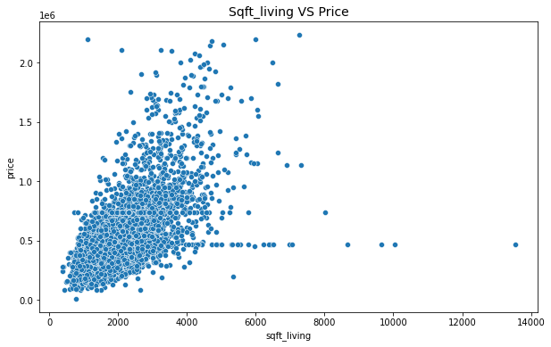

```python
plt.figure(figsize=(10,6))
ax = sns.scatterplot(data=df, x="sqft_living", y="price")
ax.set_title('Sqft_living VS Price', fontsize=14)
```

As we can observe that many of the data is less than 6000. So, let's handle this uneven data.

Removing outliers of Sqft_living using different approach.

```python
df['sqft_living'] = np.where((df.sqft_living >6000 ), 6000, df.sqft_living)
```

### And, it's done!!

Similarly, doing with rest of the continuous columns

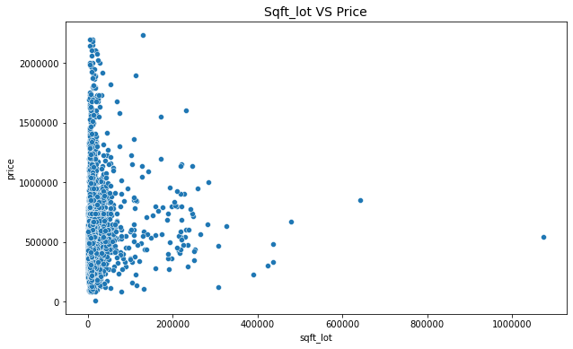

```python
plt.figure(figsize=(10,6))
ax = sns.scatterplot(data=df, x="sqft_lot", y="price")
ax.ticklabel_format(style='plain')
ax.set_title('Sqft_lot VS Price', fontsize=14)
```

Too much disturbance in this column and also as we checked above is not much correlated to our dependent column price. So, I've decided to leave it as it is.

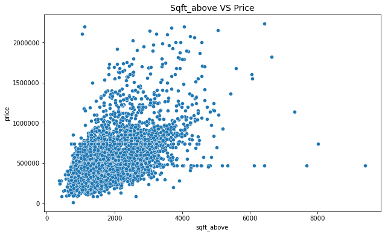

```python
plt.figure(figsize=(10,6))
ax = sns.scatterplot(data=df, x="sqft_above", y="price")
ax.ticklabel_format(style='plain')
ax.set_title('Sqft_above VS Price', fontsize=14)
```

```python
df['sqft_above'] = np.where((df.sqft_above >5000 ), 5000, df.sqft_above)
```

### And, it's done!!

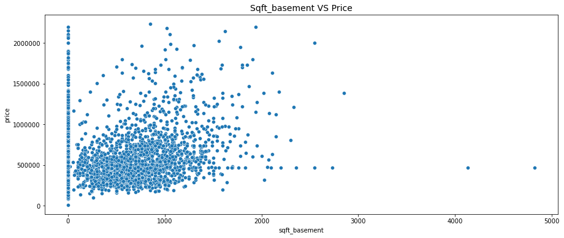

```python
plt.figure(figsize=(15,6))
ax = sns.scatterplot(data=df, x="sqft_basement", y="price")
ax.ticklabel_format(style='plain')
ax.set_title('Sqft_basement VS Price', fontsize=14)
```

Alot of 0's in sqft_basement but not an outliers because houses might have without basements.

**Note**: `not all extreme points can be treated as outlier. May they are really an authentic data.`

Still, let's make extreme large values near 2000.

```python
df['sqft_basement'] = np.where((df.sqft_basement >2000 ), 2000, df.sqft_basement)
```

#### Let's catch up with discrete variables.

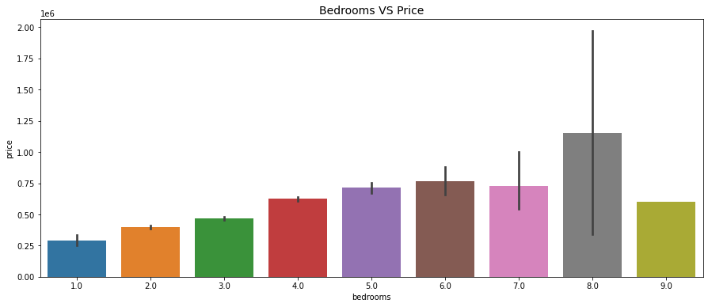

```python
plt.figure(figsize=(15,6))
ax = sns.barplot(x=df['bedrooms'], y=df['price'])
ax.set_xticklabels(ax.get_xticklabels(), rotation=0)
ax.set_title('Bedrooms VS Price', fontsize=14)
```

```python
# df.groupby(['bedrooms']).price.agg([len, min, max])
```

```python
df['bedrooms'] = np.where((df.bedrooms >6 ), 6, df.bedrooms)
```

#### And, it's done!!

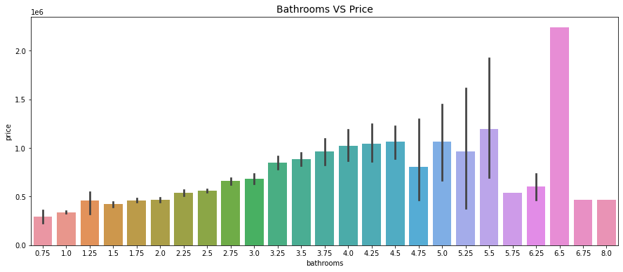

```python
plt.figure(figsize=(15,6))
ax = sns.barplot(x=df['bathrooms'], y=df['price'])
ax.set_xticklabels(ax.get_xticklabels(), rotation=0)
ax.set_title('Bathrooms VS Price', fontsize=14)
```

```python
# df.groupby(['bathrooms']).price.agg([len, min, max])
```

```python
df['bathrooms'] = np.where((df.bathrooms == 0.75), 1, df.bathrooms)
df['bathrooms'] = np.where((df.bathrooms == 1.25 ), 1, df.bathrooms)
df['bathrooms'] = np.where((df.bathrooms > 4.75 ), 5, df.bathrooms)
```

I here replaced few of less occuring entries to decrease the skewness of our distribution.

#### And, it's done!!

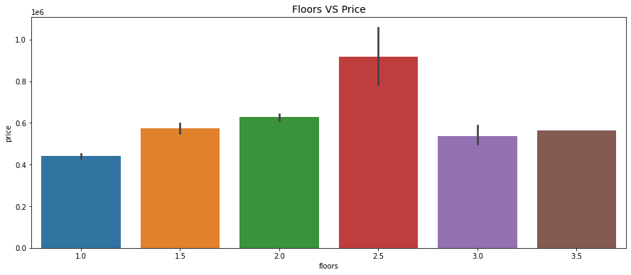

```python
plt.figure(figsize=(15,6))
ax = sns.barplot(x=df['floors'], y=df['price'])
ax.set_xticklabels(ax.get_xticklabels(), rotation=0)
ax.set_title('Floors VS Price', fontsize=14)
```

```python
# df.groupby(['floors']).price.agg([len , min, max])
```

```python
df['floors'] = np.where((df.floors == 3.5 ), 3, df.floors)
```

#### And, it's done!!

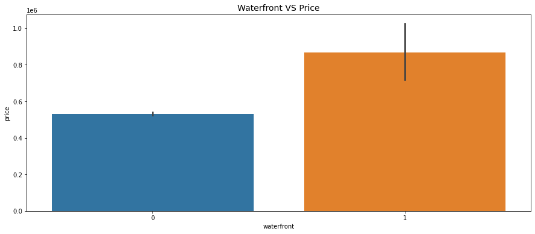

```python
plt.figure(figsize=(15,6))
ax = sns.barplot(x=df['waterfront'], y=df['price'])
ax.set_xticklabels(ax.get_xticklabels(), rotation=0)
ax.set_title('Waterfront VS Price', fontsize=14)
```

```python
# df.groupby(['waterfront']).price.agg([len , min, max])
```

No, changes for me in this column.

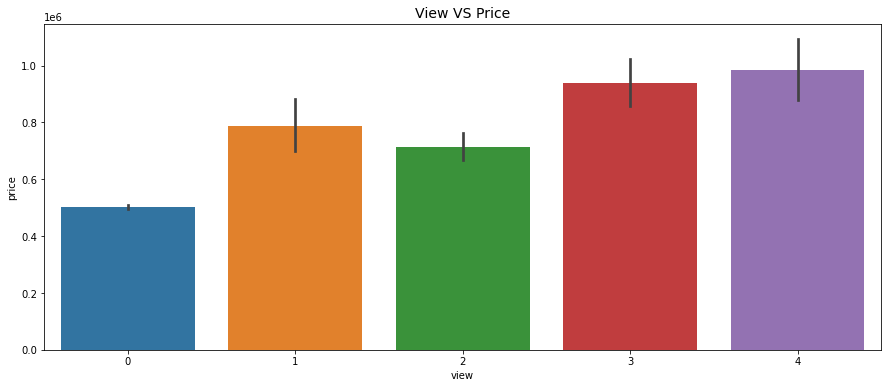

```python
plt.figure(figsize=(15,6))
ax = sns.barplot(x=df['view'], y=df['price'])
ax.set_xticklabels(ax.get_xticklabels(), rotation=0)
ax.set_title('View VS Price', fontsize=14)
```

```python
# df.groupby(['view']).price.agg([len , min, max])
```

Well no need for any changes. 0 view is for houses having no sea facing view or anything like that. So it seems pretty authentic to me.

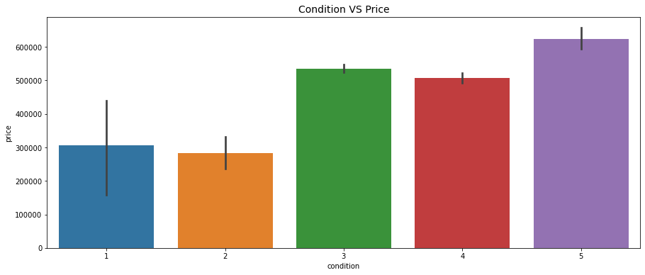

```python
plt.figure(figsize=(15,6))
ax = sns.barplot(x=df['condition'], y=df['price'])
ax.set_xticklabels(ax.get_xticklabels(), rotation=0)
ax.set_title('Condition VS Price', fontsize=14)
```

```python
# df.groupby(['condition']).price.agg([len , min, max])
```

```python
df['condition'] = np.where((df.condition == 1 ), 2, df.condition)
```

#### And, it's done!!

Done with the Discrete columns here.

Yr_built & yr_renovated are out of two least correlated columns with price. Thus, decided to leave them as it is.

#### Let's quickly check prediction with these continuous columns only except sqft_lot, yr_built and yr_renovated

```python
X = df.drop(["date",'street', 'city','statezip','sqft_lot','country','price','yr_built','yr_renovated'], axis=1)
y = df[['price']]
from sklearn.model_selection import train_test_split
train_X, test_X, train_y, test_y= train_test_split(X,y, test_size=0.3, random_state=0)

from sklearn.linear_model import LinearRegression
mlrm = LinearRegression()

mlrm.fit(train_X,train_y)

mlrm.score(train_X, train_y)*100
```

```
45.55643509254341
```

### Analysis of Relationship Between Variables

Time to drop few columns from our dataframe

```python
df.drop(["date",'yr_built','yr_renovated','sqft_lot'], axis=1, inplace = True)
```

```python
# df[df == 0].count()
```

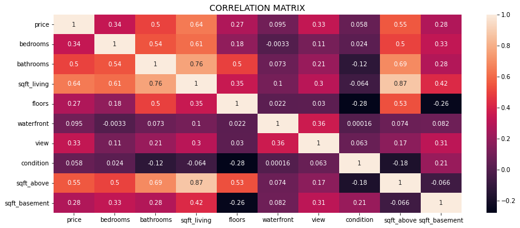

```python
plt.figure(figsize=(15,6))
ax = sns.heatmap(df.corr(),annot = True)
ax.set_title('CORRELATION MATRIX', fontsize=14)
```

Sqft_living and sqft_above are highly correlated but Sqft_abobe is less correlated with price. So we got our column which can be dropped.

Now, as you all can notice in heatmap. Columns like condition and waterfront have less impressive correlation with our dependent variable. So that I've decided to drop them as well.

```python
df.drop(['waterfront','condition','sqft_above'],axis=1, inplace=True)
```

```python
df.head()
```

|  | price | bedrooms | bathrooms | sqft_living | floors | view | sqft_basement | street | city | statezip | country |
| --- | --- | --- | --- | --- | --- | --- | --- | --- | --- | --- | --- |
| 0 | 313000.0 | 3.0 | 1.50 | 1340 | 1.5 | 0 | 0 | 18810 Densmore Ave N | Shoreline | WA 98133 | USA |
| 1 | 468250.0 | 5.0 | 2.50 | 3650 | 2.0 | 4 | 280 | 709 W Blaine St | Seattle | WA 98119 | USA |
| 2 | 342000.0 | 3.0 | 2.00 | 1930 | 1.0 | 0 | 0 | 26206-26214 143rd Ave SE | Kent | WA 98042 | USA |
| 3 | 420000.0 | 3.0 | 2.25 | 2000 | 1.0 | 0 | 1000 | 857 170th Pl NE | Bellevue | WA 98008 | USA |
| 4 | 550000.0 | 4.0 | 2.50 | 1940 | 1.0 | 0 | 800 | 9105 170th Ave NE | Redmond | WA 98052 | USA |

```python
df.info()
```

```
<class 'pandas.core.frame.DataFrame'>
Int64Index: 4598 entries, 0 to 4599
Data columns (total 11 columns):
 #   Column         Non-Null Count  Dtype
---  ------         --------------  -----
 0   price          4598 non-null   float64
 1   bedrooms       4598 non-null   float64
 2   bathrooms      4598 non-null   float64
 3   sqft_living    4598 non-null   int64
 4   floors         4598 non-null   float64
 5   view           4598 non-null   int64
 6   sqft_basement  4598 non-null   int64
 7   street         4598 non-null   object
 8   city           4598 non-null   object
 9   statezip       4598 non-null   object
 10  country        4598 non-null   object
dtypes: float64(4), int64(3), object(4)
memory usage: 560.1+ KB
```

#### Left with object types to handle. Let's start with country then street then city then statezip

```python
# df['country'].nunique()
# df['street'].nunique()
# df['city'].nunique()
# df['statezip'].nunique()
```

All the entries have common country, will never affect our dependent variable. Will drop it later

Too many unique values for 4600 entries, again will never affect our dependent variable. Will drop it later.

Just left with city and statezip. Here we all know satezip and city are quite relateable things. Like every city has a unique zip code. So, we have to choose wisely one out of these two columns

```python
# city = df.groupby(['city']).price.agg([len, min, max])
# pd.set_option('display.max_rows',70)
# city
```

```python
# plt.figure(figsize=(15,10))
# ax = sns.barplot(x="city", y="price", data=df)
# ax.set_xticklabels(ax.get_xticklabels(), rotation=90, ha="right");
```

```python
# statezip = df.groupby(['statezip']).price.agg([len, min, max])
# pd.set_option('display.max_rows',70)
# statezip
```

```python
# plt.figure(figsize=(15,10))
# ax = sns.barplot(x="statezip", y="price", data=df)
# ax.set_xticklabels(ax.get_xticklabels(), rotation=90, ha="right");
```

You can observe a litle high variation in statezip in comparison to city. So I'have selected our final column that is statezip.

Now, let's drop street, city and country before moving forward.

```python
df.drop(['street','city','country'],axis=1, inplace=True)
```

Categorical Features Transformation

```python
df = pd.get_dummies(df, columns=['statezip'], prefix = ['statezip'])
df.head()
```

|  | price | bedrooms | bathrooms | sqft_living | floors | view | sqft_basement | statezip_WA 98001 | statezip_WA 98002 | statezip_WA 98003 | ... | statezip_WA 98155 | statezip_WA 98166 | statezip_WA 98168 | statezip_WA 98177 | statezip_WA 98178 | statezip_WA 98188 | statezip_WA 98198 | statezip_WA 98199 | statezip_WA 98288 | statezip_WA 98354 |
| --- | --- | --- | --- | --- | --- | --- | --- | --- | --- | --- | --- | --- | --- | --- | --- | --- | --- | --- | --- | --- | --- |
| 0 | 313000.0 | 3.0 | 1.50 | 1340 | 1.5 | 0 | 0 | 0 | 0 | 0 | ... | 0 | 0 | 0 | 0 | 0 | 0 | 0 | 0 | 0 | 0 |
| 1 | 468250.0 | 5.0 | 2.50 | 3650 | 2.0 | 4 | 280 | 0 | 0 | 0 | ... | 0 | 0 | 0 | 0 | 0 | 0 | 0 | 0 | 0 | 0 |
| 2 | 342000.0 | 3.0 | 2.00 | 1930 | 1.0 | 0 | 0 | 0 | 0 | 0 | ... | 0 | 0 | 0 | 0 | 0 | 0 | 0 | 0 | 0 | 0 |
| 3 | 420000.0 | 3.0 | 2.25 | 2000 | 1.0 | 0 | 1000 | 0 | 0 | 0 | ... | 0 | 0 | 0 | 0 | 0 | 0 | 0 | 0 | 0 | 0 |
| 4 | 550000.0 | 4.0 | 2.50 | 1940 | 1.0 | 0 | 800 | 0 | 0 | 0 | ... | 0 | 0 | 0 | 0 | 0 | 0 | 0 | 0 | 0 | 0 |

5 rows × 84 columns

```python
df.shape
# df.columns
```

```
(4598, 84)
```

## Modeling

Now, we will train our model divide for train, test and validation dataset.

**Training Dataset**: The sample of data used to fit the model.

**Validation Dataset**: The sample of data used to provide an unbiased evaluation of a model fit on the training dataset while tuning model hyperparameters. The evaluation becomes more biased as skill on the validation dataset is incorporated into the model configuration.

**Test Dataset**: The sample of data used to provide an unbiased evaluation of a final model fit on the training dataset.

Apply Linear Regression and hence, it's done.

### Train the model --------> Using (LinearRegression)

#### Then --> Predict 'price' from train data Then test data

```python
from sklearn.preprocessing import StandardScaler
```

```python
X = df.drop(["price"],axis = 1)
y = df["price"]

from sklearn.model_selection import train_test_split
train_X, test_X, train_y, test_y= train_test_split(X,y, test_size=0.2, random_state=8)

scaler=StandardScaler()
scaler.fit(train_X)
train_X_s = scaler.transform(train_X)
test_X_s = scaler.transform(test_X)

from sklearn.linear_model import LinearRegression
mlrm = LinearRegression()

mlrm.fit(train_X,train_y)

mlrm.score(train_X, train_y)*100
```

```
67.88069229415551
```

```python
X_val, X_test, y_val, y_test = train_test_split(test_X, test_y, test_size=0.5, random_state=5)
```

```python
mlrm.score(X_val, y_val)*100
```

```
66.35848150327628
```

```python
mlrm.score(X_test, y_test)*100
```

```
73.61484889805787
```

```python
import statsmodels.api as sm
mod = sm.OLS(train_y, train_X)
res = mod.fit()
print(res.summary())
```

```
                            OLS Regression Results
==============================================================================
Dep. Variable:                  price   R-squared:                       0.679
Model:                            OLS   Adj. R-squared:                  0.672
Method:                 Least Squares   F-statistic:                     93.82
Date:                Wed, 06 Jul 2022   Prob (F-statistic):               0.00
Time:                        21:39:46   Log-Likelihood:                -49547.
No. Observations:                3678   AIC:                         9.926e+04
Df Residuals:                    3596   BIC:                         9.977e+04
Df Model:                          81
Covariance Type:            nonrobust
=====================================================================================
                        coef    std err          t      P>|t|      [0.025      0.975]
-------------------------------------------------------------------------------------
bedrooms          -1388.3375   4260.600     -0.326      0.745   -9741.771    6965.096
bathrooms          1.356e+04   6492.315      2.088      0.037     829.496    2.63e+04
sqft_living         179.1376      6.206     28.867      0.000     166.971     191.305
floors            -3.024e+04   7842.378     -3.857      0.000   -4.56e+04   -1.49e+04
view               5.876e+04   4239.598     13.859      0.000    5.04e+04    6.71e+04
sqft_basement       -90.2753      9.250     -9.759      0.000    -108.411     -72.139
statezip_WA 98001 -1.668e+04   2.71e+04     -0.616      0.538   -6.97e+04    3.64e+04
statezip_WA 98002 -1.386e+04   3.42e+04     -0.406      0.685   -8.08e+04    5.31e+04
statezip_WA 98003 -3.342e+04   3.02e+04     -1.108      0.268   -9.26e+04    2.57e+04
statezip_WA 98004  6.217e+05   2.64e+04     23.513      0.000     5.7e+05    6.74e+05
statezip_WA 98005  3.635e+05   3.88e+04      9.360      0.000    2.87e+05     4.4e+05
statezip_WA 98006  3.265e+05   2.33e+04     14.002      0.000    2.81e+05    3.72e+05
statezip_WA 98007  3.065e+05   3.56e+04      8.598      0.000    2.37e+05    3.76e+05
statezip_WA 98008  2.039e+05   2.98e+04      6.849      0.000    1.46e+05    2.62e+05
statezip_WA 98010  6.184e+04   6.66e+04      0.928      0.353   -6.88e+04    1.92e+05
statezip_WA 98011    1.1e+05   3.75e+04      2.934      0.003    3.65e+04    1.84e+05
statezip_WA 98014  9.123e+04   4.29e+04      2.128      0.033    7185.489    1.75e+05
statezip_WA 98019  5.072e+04   3.21e+04      1.578      0.115   -1.23e+04    1.14e+05
statezip_WA 98022 -1.763e+04   3.82e+04     -0.462      0.644   -9.25e+04    5.73e+04
statezip_WA 98023 -3.621e+04   2.47e+04     -1.466      0.143   -8.46e+04    1.22e+04
statezip_WA 98024  1.983e+05   5.97e+04      3.325      0.001    8.14e+04    3.15e+05
statezip_WA 98027  1.793e+05   2.45e+04      7.326      0.000    1.31e+05    2.27e+05
statezip_WA 98028  1.225e+05   2.66e+04      4.605      0.000    7.04e+04    1.75e+05
statezip_WA 98029  2.302e+05    2.6e+04      8.839      0.000    1.79e+05    2.81e+05
statezip_WA 98030 -2.251e+04   3.23e+04     -0.696      0.486   -8.59e+04    4.09e+04
statezip_WA 98031 -7887.2184   2.78e+04     -0.284      0.777   -6.24e+04    4.66e+04
```

[output cut: 53 more lines]

```
statezip_WA 98198 -2.333e+04   2.74e+04     -0.852      0.394    -7.7e+04    3.04e+04
statezip_WA 98199  3.754e+05   2.78e+04     13.480      0.000    3.21e+05     4.3e+05
statezip_WA 98288 -1.857e+04   1.23e+05     -0.151      0.880    -2.6e+05    2.23e+05
statezip_WA 98354  7.086e+04   1.23e+05      0.575      0.565   -1.71e+05    3.12e+05
==============================================================================
Omnibus:                     1056.773   Durbin-Watson:                   2.013
Prob(Omnibus):                  0.000   Jarque-Bera (JB):            52148.883
Skew:                           0.576   Prob(JB):                         0.00
Kurtosis:                      21.411   Cond. No.                     3.63e+19
==============================================================================

Notes:
[1] Standard Errors assume that the covariance matrix of the errors is correctly specified.
[2] The smallest eigenvalue is 1.56e-29. This might indicate that there are
strong multicollinearity problems or that the design matrix is singular.
```

```python
# X = df.drop(["price"],axis = 1)
# y = df["price"]

from sklearn.model_selection import train_test_split
X_train, X_test, y_train, y_test= train_test_split(X,y, test_size=0.2, random_state=42)
```

### 1- Train the model --------> Using (DecisionTreeRegressor)

#### Then --> Predict 'price' from train data Then test data

```python
from sklearn.metrics import accuracy_score, fbeta_score, r2_score

from sklearn.tree import DecisionTreeRegressor, export_text, plot_tree

clf1 = DecisionTreeRegressor()    # max_depth=5, min_samples_leaf=4

clf1.fit(X_train,y_train) # Learn
y_pred_training = clf1.predict(X_train)
# y_pred_training
print("accuracy_score train : ", r2_score(y_train,y_pred_training) * 100)
```

```
accuracy_score train :  99.95087633265376
```

```python
# print( export_text(clf1, feature_names=list(X_train.columns)) )
```

```python
# fig = plt.figure(figsize=(80,80))
# plot_tree( clf1, feature_names=list(X_train.columns), class_names=list(df['price'].keys()), filled=True )
# plt.show()
```

```python
y_pred_test = clf1.predict(X_test)
print("accuracy_score test : ", r2_score(y_test,y_pred_test)* 100)
```

```
accuracy_score test :  45.80970933437656
```

### 2- Train the model --------> Using (RandomForestRegressor)

#### Then --> Predict 'price' from train data Then test data

```python
from sklearn.ensemble import RandomForestRegressor

clf2 = RandomForestRegressor(random_state=42, oob_score=True)

clf2.fit(X_train,y_train) # Learn
y_pred_training = clf2.predict(X_train)
# y_pred_training
print("accuracy_score train : ", r2_score(y_train,y_pred_training) * 100)
```

```
accuracy_score train :  94.8302138877822
```

```python
print(clf2.oob_score_ * 100)
```

```
62.14244070224788
```

```python
y_pred_test = clf2.predict(X_test)
print("accuracy_score test : ", r2_score(y_test,y_pred_test)* 100)
```

```
accuracy_score test :  66.63245888523161
```

### 3- Train the model --------> Using (AdaBoostRegressor)

#### Then --> Predict 'price' from train data Then test data

```python
from sklearn.ensemble import AdaBoostRegressor

clf3 = AdaBoostRegressor(random_state=42, n_estimators=50, learning_rate=1)

clf3.fit(X_train,y_train) # Learn
y_pred_training = clf3.predict(X_train)
# y_pred_training
print("accuracy_score train : ", r2_score(y_train,y_pred_training) * 100)
```

```
accuracy_score train :  42.60042398595779
```

```python
y_pred_test = clf3.predict(X_test)
print("accuracy_score test : ", r2_score(y_test,y_pred_test)* 100)
```

```
accuracy_score test :  37.442575529603374
```

### 4- Train the model --------> Using (GradientBoostingRegressor)

#### Then --> Predict 'price' from train data Then test data

```python
from sklearn.ensemble import GradientBoostingRegressor

clf4 = GradientBoostingRegressor(random_state=0) # learning_rate=0.5
clf4.fit(X_train,y_train) # Learn
y_pred_training = clf4.predict(X_train)
# y_pred_training
print("accuracy_score train : ", r2_score(y_train,y_pred_training) * 100)
```

```
accuracy_score train :  70.03910772756856
```

```python
y_pred_test = clf4.predict(X_test)
print("accuracy_score test : ", r2_score(y_test,y_pred_test)* 100)
```

```
accuracy_score test :  63.98063957878054
```